# Glossary

Download R Markdown source (.Rmd)

This glossary supports Module 6 (Sampling Distributions and the Central Limit Theorem). Entries are listed alphabetically. Each entry gives a definition, a cited source, and examples with by-hand work and R code. The examples use fresh contexts and values so they extend, rather than repeat, the course readings and assessments.

## C

### Central Limit Theorem

Definition: The result that, for independent observations with mean \(\mu\) and standard deviation \(\sigma\), the standardized sample mean $$ Z_n=\frac{\bar X-\mu}{\sigma/\sqrt n} $$ approaches a standard normal distribution as \(n\) grows. Equivalently, for large \(n\), \(\bar X\) is approximately normal with mean \(\mu\) and standard error \(\sigma/\sqrt n\). The theorem describes the shape of the sampling distribution, not the shape of the raw data.

Source: Mathematical Statistics with Applications in R, Chapter 4; Introductory Statistics 2e, Chapter 7.

Example 1: A strongly right-skewed population has mean 10 and standard deviation 10. Samples of size 81 are selected.

By hand: The sampling distribution of \(\bar X\) has mean 10 and standard error \(10/\sqrt{81}=1.111\). Because \(n=81>30\), the CLT makes the sampling distribution approximately normal.

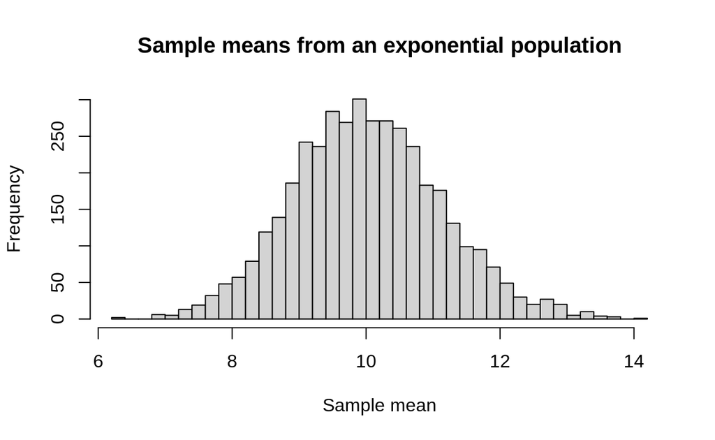

```r
# Set a seed so the simulation is reproducible.
set.seed(390)

# Draw 4,000 sample means, each from 81 exponential observations
# with population mean 10 and population standard deviation 10.
sample_means <- replicate(
  4000,
  mean(rexp(81, rate = 1 / 10))
)

# Plot the sample means. The histogram should be centered near 10 and
# approximately normal because n = 81 is large enough for the CLT.
hist(
  sample_means,
  breaks = 40,
  main = "Sample means from an exponential population",
  xlab = "Sample mean"
)
```

Example 2: A population is approximately normal with mean 150 and standard deviation 12. Samples of size 25 are selected.

By hand: The sampling distribution is exactly normal with mean 150 and standard error \(12/5=2.4\). The CLT is not needed because the population is already normal.

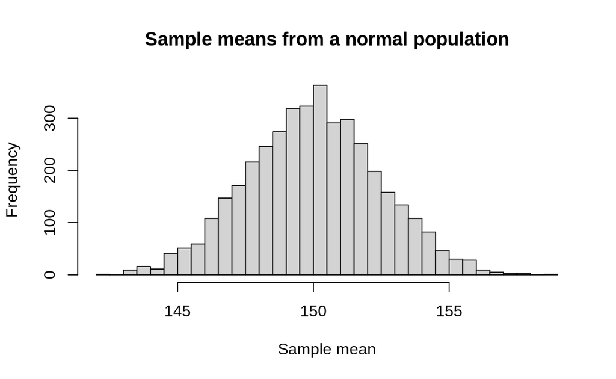

```r
# Set a seed so the simulation is reproducible.
set.seed(390)

# Draw 4,000 sample means from a normal population with mean 150 and
# standard deviation 12. Each sample contains 25 observations.
sample_means <- replicate(
  4000,
  mean(rnorm(25, mean = 150, sd = 12))
)

# The sampling distribution is normal because the population is normal,
# not because of the central limit theorem.
hist(
  sample_means,
  breaks = 40,
  main = "Sample means from a normal population",
  xlab = "Sample mean"
)
```

## E

### Expected Value of the Sample Mean

Definition: The long-run average value of the sample mean over repeated random samples. For independent observations from a population with mean \(\mu\), the expected value of the sample mean is \(\mu\). Using linearity of expectation, $$ E(\bar X) = E\left(\frac1n\sum_{i=1}^n X_i\right) = \frac1n\sum_{i=1}^n E(X_i) = \frac1n\sum_{i=1}^n \mu = \mu. $$

Source: Mathematical Statistics with Applications in R, Chapter 4.

Example 1: A population has mean 85 and standard deviation 24. Samples of size 64 are selected.

By hand: The expected value of \(\bar X\) is 85, the population mean. The sample size does not change the center.

```r
# Set a seed so the simulation is reproducible.
set.seed(390)

# Create a large population with mean 85 and standard deviation 24.
population <- rnorm(200000, mean = 85, sd = 24)

# Draw 4,000 sample means, each based on 64 observations.
sample_means <- replicate(
  4000,
  mean(sample(population, 64, replace = TRUE))
)

# The average of the sample means should be close to the population mean.
mean(sample_means)
[1] 85.0604
```

```r
# Store eight response times (more than four observations).
response_time <- c(120, 90, 150, 100, 130, 110, 95, 160)

# Draw 4,000 sample means, each based on 5 observations sampled with
# replacement from the response-time population.
sample_means <- replicate(
  4000,
  mean(sample(response_time, 5, replace = TRUE))
)

# Compare the average sample mean to the population mean.
mean(response_time)
[1] 119.375
mean(sample_means)
[1] 119.4327
```

## L

### Law of Large Numbers

Definition: The result that the sample mean tends to get closer to the population mean as the sample size grows. It describes the behavior of the average in large samples, while the central limit theorem describes the shape of the sampling distribution around that average.

Source: Introductory Statistics 2e, Chapter 7.

Example 1: A fair coin is flipped many times and the proportion of heads is recorded.

By hand: As the number of flips grows, the proportion of heads tends to get closer to 0.5.

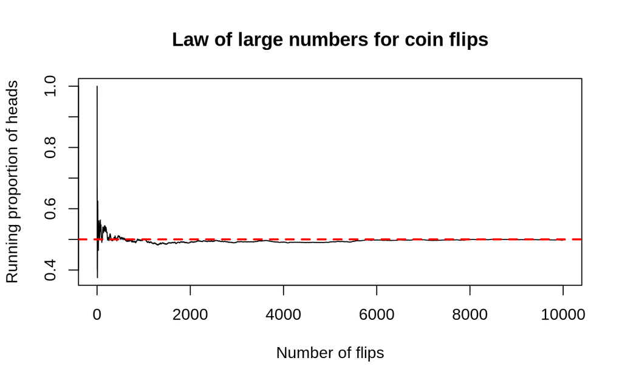

```r
# Set a seed so the simulation is reproducible.
set.seed(390)

# Simulate 10,000 flips of a fair coin.
flips <- rbinom(10000, size = 1, prob = 0.5)

# Compute the running proportion of heads after each flip.
running_proportion <- cumsum(flips) / seq_along(flips)

# Plot the running proportion. It should move toward 0.5 as the number
# of flips grows.
plot(
  running_proportion,
  type = "l",
  main = "Law of large numbers for coin flips",
  xlab = "Number of flips",
  ylab = "Running proportion of heads"
)
abline(h = 0.5, col = "red", lwd = 2, lty = 2)
```

Example 2: A population has eight response times. The average of increasingly large samples is recorded.

By hand: As the sample size grows, the sample mean tends to get closer to the population mean.

```r
# Store eight response times (more than four observations).
response_time <- c(120, 90, 150, 100, 130, 110, 95, 160)

# Set a seed so the simulation is reproducible.
set.seed(390)

# Compute one sample mean for each of several sample sizes.
sample_means <- sapply(
  c(5, 16, 64),
  function(n) mean(sample(response_time, n, replace = TRUE))
)

# Compare the sample means to the population mean.
mean(response_time)
[1] 119.375
sample_means
[1] 136.0000 125.0000 119.6094
```

## P

### Population Distribution

Definition: The distribution of a variable across the entire population. It is fixed but usually unknown. It should be distinguished from the distribution of a sample and from the sampling distribution of a statistic.

Source: Mathematical Statistics with Applications in R, Chapter 4.

Example 1: Query latencies for all possible requests form a strongly right-skewed population distribution.

By hand: The population distribution describes individual query times. It is not the distribution of sample means.

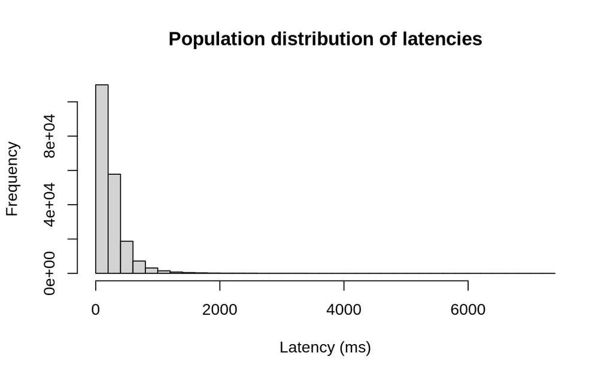

```r
# Set a seed so the simulated population is reproducible.
set.seed(390)

# Simulate a large right-skewed population of query latencies.
population <- rlnorm(200000, meanlog = 5.2, sdlog = 0.8)

# Plot the population distribution. This describes individual observations.
hist(
  population,
  breaks = 50,
  main = "Population distribution of latencies",
  xlab = "Latency (ms)"
)
```

```r
# Summarize the population center and spread.
mean(population)
[1] 250.014
sd(population)
[1] 237.0608
```

Example 2: A measurement is normally distributed with mean 150 and standard deviation 12.

By hand: The population distribution describes individual measurements. The sampling distribution of the mean is a different distribution.

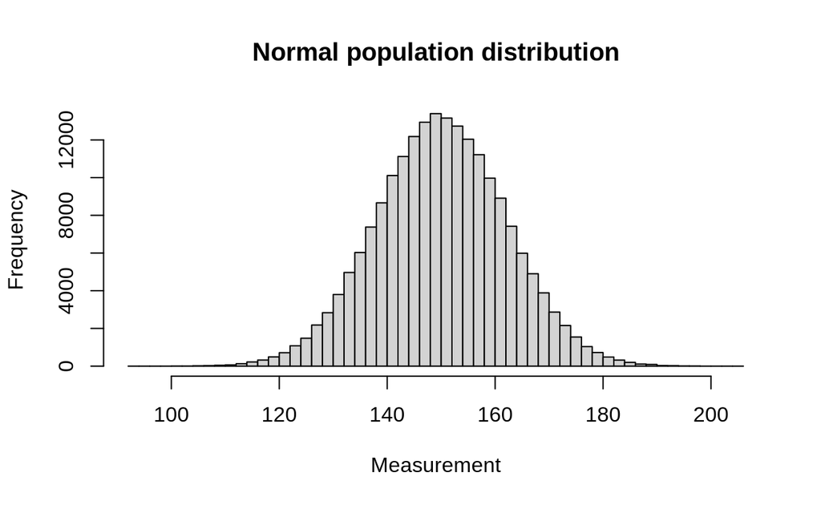

```r
# Set a seed so the simulated population is reproducible.
set.seed(390)

# Simulate a large normal population with mean 150 and standard deviation 12.
population <- rnorm(200000, mean = 150, sd = 12)

# Plot the population distribution.
hist(
  population,
  breaks = 50,
  main = "Normal population distribution",
  xlab = "Measurement"
)
```

```r
# Summarize the population center and spread.
mean(population)
[1] 150.0013
sd(population)
[1] 12.03175
```

## S

### Sample Size

Definition: The number of observations in a sample, usually denoted \(n\). It affects the standard error through the factor \(1/\sqrt n\) and affects whether the central limit theorem is a reasonable justification for a normal model.

Source: Mathematical Statistics with Applications in R, Chapter 4.

Example 1: A population has standard deviation 120. Compare sample sizes 9, 25, 64, and 100.

By hand: The standard errors are \(120/3=40\), \(120/5=24\), \(120/8=15\), and \(120/10=12\). Larger samples have smaller standard errors.

```r
# Set the population standard deviation.
sigma <- 120

# Choose several sample sizes to compare.
sample_sizes <- c(9, 25, 64, 100)

# Compute the standard error for each sample size.
standard_errors <- sigma / sqrt(sample_sizes)

# Display the sample sizes and standard errors together.
data.frame(
  sample_size = sample_sizes,
  standard_error = standard_errors
)
  sample_size standard_error
1           9             40
2          25             24
3          64             15
4         100             12
```

Example 2: A population has standard deviation 10. Compare the spread of sample means for sample sizes 16 and 64.

By hand: The larger sample has less variability among the sample means because its standard error is smaller.

```r
# Set a seed so the simulation is reproducible.
set.seed(390)

# Create a large right-skewed population with mean 10 and standard deviation 10.
population <- rexp(200000, rate = 1 / 10)

# Draw 4,000 sample means for a smaller sample size.
small_sample_means <- replicate(
  4000,
  mean(sample(population, 16, replace = TRUE))
)

# Draw 4,000 sample means for a larger sample size.
large_sample_means <- replicate(
  4000,
  mean(sample(population, 64, replace = TRUE))
)

# The larger sample should have less variability among the sample means.
sd(small_sample_means)
[1] 2.502958
sd(large_sample_means)
[1] 1.27364
```

### Sampling Distribution

Definition: The probability distribution of a statistic over repeated random samples of the same size from the same population. For the sample mean, the center and standard error depend only on the population mean \(\mu\), population standard deviation \(\sigma\), and sample size \(n\): $$ E(\bar X)=\mu, \qquad \operatorname{SE}(\bar X)=\frac{\sigma}{\sqrt n}. $$ The full population distribution is not needed to compute those two quantities. The population shape matters for the shape of the sampling distribution and for deciding whether a normal approximation is justified.

Source: Mathematical Statistics with Applications in R, Chapter 4; Introductory Statistics 2e, Chapter 7.

Example 1: A population has mean 85 and standard deviation 24. Samples of size 64 are selected.

By hand: The sampling distribution of \(\bar X\) has mean 85 and standard error \(24/8=3\). Its shape depends on the population shape and the sample size.

```r
# Set a seed so the simulation is reproducible.
set.seed(390)

# Create a large population with mean 85 and standard deviation 24.
population <- rnorm(200000, mean = 85, sd = 24)

# Draw 4,000 sample means, each based on 64 observations.
sample_means <- replicate(
  4000,
  mean(sample(population, 64, replace = TRUE))
)

# The sampling distribution is centered near 85 with a smaller spread
# than the population of individual observations.
mean(sample_means)
[1] 85.0604
sd(sample_means)
[1] 3.005515
```

Example 2: The population mean and standard deviation are known, but the full population distribution is not needed.

By hand: The center and standard error of the sampling distribution can be computed directly from \(\mu\), \(\sigma\), and \(n\).

```r
# Set the population mean, population standard deviation, and sample size.
mu <- 85
sigma <- 24
n <- 64

# Compute the center and standard error of the sampling distribution
# without specifying the full population distribution.
c(
  mean = mu,
  standard_error = sigma / sqrt(n)
)
          mean standard_error
            85              3
```

### Sampling Variability

Definition: The natural variation in a statistic from one random sample to another. Sampling variability is described by the sampling distribution and measured in part by the standard error.

Source: Introductory Statistics 2e, Chapter 7.

Example 1: Two analysts each take a random sample of 25 requests and compute the average latency.

By hand: They will generally get different sample means because of sampling variability.

```r
# Set a seed so the simulation is reproducible.
set.seed(390)

# Create a large right-skewed population of request latencies.
population <- rlnorm(200000, meanlog = 5.2, sdlog = 0.8)

# Draw two independent sample means, each from 25 observations.
two_sample_means <- replicate(
  2,
  mean(sample(population, 25, replace = TRUE))
)

# The two sample means will generally differ.
two_sample_means
[1] 272.4371 268.9886
```

Example 2: A simulation draws 1,000 different samples of size 64 from the same population.

By hand: The spread of the 1,000 sample means describes the sampling variability.

```r
# Set a seed so the simulation is reproducible.
set.seed(390)

# Create a large right-skewed population of request latencies.
population <- rlnorm(200000, meanlog = 5.2, sdlog = 0.8)

# Draw 1,000 sample means, each based on 64 observations.
sample_means <- replicate(
  1000,
  mean(sample(population, 64, replace = TRUE))
)

# The standard deviation of the sample means describes sampling variability.
sd(sample_means)
[1] 30.2813
```

### Standard Deviation

Definition: A measure of the spread of individual observations around their mean, equal to the square root of the variance. It describes the population or sample, not the variability of a sample mean.

Source: Mathematical Statistics with Applications in R, Chapter 1; Introductory Statistics 2e, Chapter 2.

Example 1: A population has standard deviation 24. A sample of size 64 is selected.

By hand: The standard deviation of individual observations is 24. The standard error of the sample mean is \(24/\sqrt{64}=3\).

```r
# Set a seed so the simulated population is reproducible.
set.seed(390)

# Create a large population with mean 85 and standard deviation 24.
population <- rnorm(200000, mean = 85, sd = 24)

# The population standard deviation describes individual observations.
sd(population)
[1] 24.0635

# The standard error describes the variability of the sample mean.
sd(population) / sqrt(64)
[1] 3.007937
```

Example 2: A sample of ten latencies has a sample standard deviation.

By hand: The sample standard deviation summarizes the spread of the individual observations. It is not the standard error of the sample mean.

```r
# Store ten response times (more than four observations).
response_time <- c(
  120, 90, 150, 100, 130,
  110, 95, 160, 140, 105
)

# The sample mean summarizes the center of the observations.
mean(response_time)
[1] 120

# The sample standard deviation summarizes the spread of the observations.
sd(response_time)
[1] 24.15229
```

### Standard Error

Definition: The standard deviation of a statistic’s sampling distribution. For the sample mean from independent observations, the standard error is \(\sigma/\sqrt n\), or \(s/\sqrt n\) when the population standard deviation is estimated by the sample standard deviation.

Source: Mathematical Statistics with Applications in R, Chapter 4; Introductory Statistics 2e, Chapter 7.

Example 1: A population has standard deviation 120. Samples of size 64 are selected.

By hand: The standard error of the sample mean is \(120/\sqrt{64}=15\).

```r
# Set the population standard deviation and sample size.
sigma <- 120
n <- 64

# Compute the standard error of the sample mean.
sigma / sqrt(n)
[1] 15
```

Example 2: A pilot sample has standard deviation 122.4. A future sample of size 64 is planned.

By hand: The estimated standard error is \(122.4/\sqrt{64}=15.3\). This is an estimate because the population standard deviation is unknown.

```r
# Set the sample standard deviation from the pilot sample.
s <- 122.4

# Set the sample size planned for the future study.
n <- 64

# Estimate the standard error using the sample standard deviation.
s / sqrt(n)
[1] 15.3
```

## V

### Variance of the Sample Mean

Definition: The variance of the sampling distribution of the sample mean. For independent observations with population variance \(\sigma^2\), $$ \operatorname{Var}(\bar X) = \operatorname{Var}\left(\frac1n\sum_{i=1}^n X_i\right) = \frac{1}{n^2}\sum_{i=1}^n \operatorname{Var}(X_i) + \frac{2}{n^2}\sum_{i<j}\operatorname{Cov}(X_i,X_j). $$ Independence makes every covariance term zero, so $$ \operatorname{Var}(\bar X) = \frac{1}{n^2}\sum_{i=1}^n \sigma^2 = \frac{n\sigma^2}{n^2} = \frac{\sigma^2}{n}. $$ The standard error is the square root of this variance, \(\sigma/\sqrt n\).

Source: Mathematical Statistics with Applications in R, Chapter 4.

Example 1: A population has standard deviation 24. Samples of size 64 are selected.

By hand: The variance of the sample mean is \(24^2/64=9\), so the standard error is \(\sqrt9=3\).

```r
# Set the population standard deviation and sample size.
sigma <- 24
n <- 64

# Compute the variance of the sample mean.
variance_of_mean <- sigma^2 / n

# Compute the standard error by taking the square root.
standard_error <- sqrt(variance_of_mean)

variance_of_mean
[1] 9
standard_error
[1] 3
```

Example 2: A population has mean 85 and standard deviation 24. Samples of size 64 are simulated.

By hand: The simulated variance of the sample means should be close to \(24^2/64=9\).

```r
# Set a seed so the simulation is reproducible.
set.seed(390)

# Create a large population with mean 85 and standard deviation 24.
population <- rnorm(200000, mean = 85, sd = 24)

# Draw 4,000 sample means, each based on 64 observations.
sample_means <- replicate(
  4000,
  mean(sample(population, 64, replace = TRUE))
)

# The variance of the sample means should be close to sigma^2 / n.
var(sample_means)
[1] 9.033122
sd(sample_means)
[1] 3.005515
```